*Note: These are notes live-tex’d from a graduate course in Contact Topology taught by Peter Lambert-Cole at the University of Georgia in Spring 2022. As such, any errors or inaccuracies are almost certainly my own.*

# Contact Topology

Lectures by Peter Lambert-Cole. University of Georgia, Spring 2022

D. Zack Garza

University of Georgia  
dzackgarza@gmail.com

Last updated: 2022-05-29

# 1 Tuesday, January 11

References:

- https://www.ma.imperial.ac.uk/~ssivek/courses/12s-math273.php
- https://web.ma.utexas.edu/users/gdavtor/notes/contact_notes.pdf
- [PLC’s Notes](https://outlookuga-my.sharepoint.com/:f:/g/personal/pbl20394_uga_edu/EjT_H9wRyAhAsZodxgXOgU0BSIYbqWav8X1jZY5v3RxqJA?e=n6dfVJ)

Emphasis for the course: applications to low-dimensional topology, lots of examples, and ways to construct contact structures. The first application is critical to 4-manifold theory:

## 1.1 Application 1

Every diffeomorphism $f: S^3\to S^3$ extends to a diffeomorphism ${\mathbb{B}}^4\to {\mathbb{B}}^4$.

This isn’t true in all dimensions! This is essentially what makes Kirby calculus on 4-manifolds possible without needing to track certain attaching data.

There is a standard contact structure on $S^3$: regard ${\mathbb{C}}^2 \cong {\mathbb{R}}^4$ and suppose $f:S^3\to S^3$. There is an intrinsic property of contact structures called *tightness* which doesn’t change under diffeomorphisms and is fundamental to 3-manifold topology.

There is a unique tight contact structure $\xi_\text{std}$ on $S^3$.

So up to isotopy, $f$ fixes $\xi_\text{std}$.

A useful idea: tiling by holomorphic discs. This involves taking $S^1$ and foliating the bounded disc by geodesics – by the magic of elliptic PDEs, this is unobstructed and can be continued throughout the disc just using convexity near the boundary. In higher dimensions: ${\mathbb{B}}^4$ is foliated by a 2-dimensional family of holomorphic discs.

## 1.2 Application 2

Another application: monotonic simplification (?) of the unknot. Given a knot $K \hookrightarrow S^3$, a theorem of Alexander says $K$ can be braided about the $z{\hbox{-}}$axis, which can be described by a word $w\in B_n$, the braid group
$$\begin{align*}
B_n = \left\{{ \sigma_1,\cdots, \sigma_{n-1} {~\mathrel{\Big\vert}~}[\sigma_i, \sigma_j] = 1 \,{\left\lvert {i-j} \right\rvert}\geq 2,\, \sigma_i \sigma_{i+1}\sigma_i = \sigma_{i+1}\sigma_i \sigma_{i+1}\, i=1,\cdots, n-2 }\right\}
.\end{align*}
This captures positive vs negative braiding on nearby strands, commuting of strands that are far apart, and the Reidemeister 3 move. Write \(K = K(\beta)\) for \(\beta\) a braid for the braid closure.$$

Markov’s theorem: if $K = K(\beta_1), K(\beta_2)$ where $\beta_1 \in B_n$ and $\beta_2\in B_m$ with $m,n$ not necessarily equal, then there is a sequence of Markov moves $\beta_1$ to $\beta_2$. The moves are:

- Stabilization and destabilization:

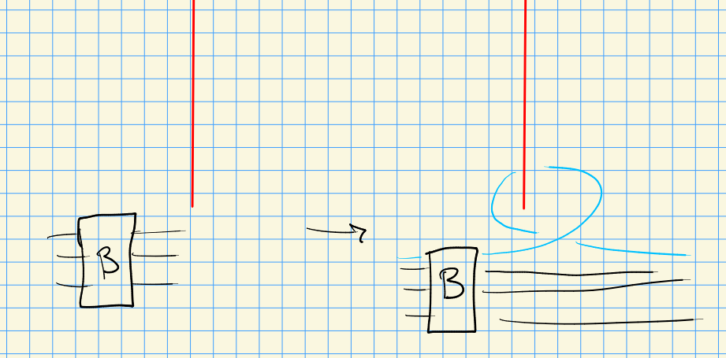

- Conjugation in $B_n$:

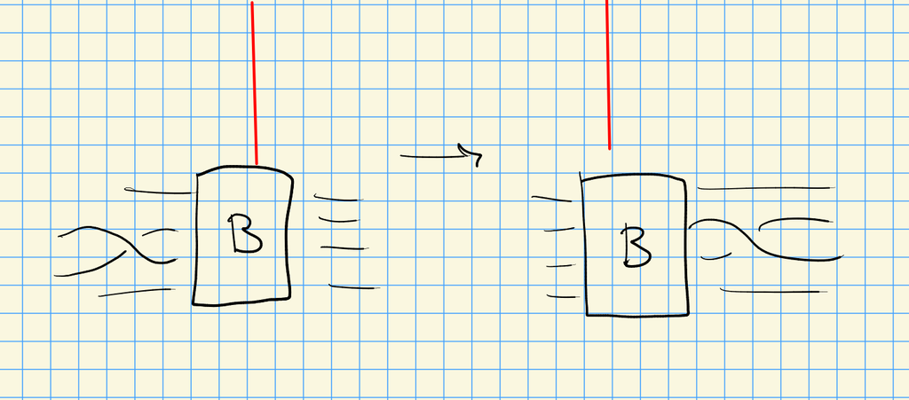

- Braid isotopy, which preserves braid words in $B_n$.

A theorem of Birman-Menasco: if $K(\beta) = U$ is the unknot for $\beta \in B_n$, then there is a sequence of braids $\left\{{\beta_i}\right\}_{i\leq k}$ with $\beta_k = 1 \in B_1$ such that

- $\beta_i\in B_{n_i}$
- $K(\beta_i) = U$
- $n_1\geq n_2\geq \cdots \geq n_k = 1$
- $\beta_i \to \beta_{i+1}$ is either a Markov move or an exchange move.

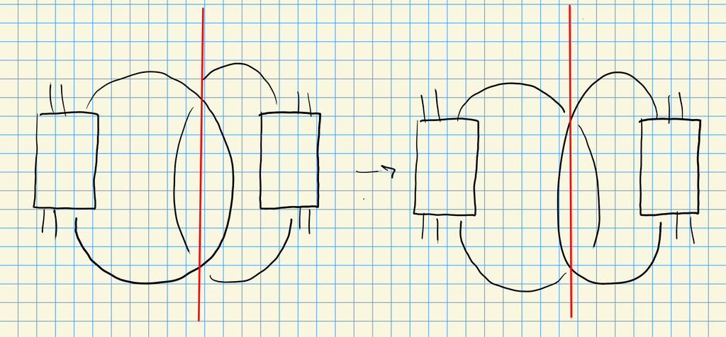

## 1.3 Application 3

Taut foliations: the basic example is $F\times S^1$ for $F$ a surface. The foliation carries a co-orientation, and the tangencies at critical points of an embedded surface will have tangent planes tangent to the foliation, so one can compare the co-orientation to the outward normal of the surface to see if they agree or disagree and obtain a sign at each critical point. Write $c_\pm$ for the number of positive/negative elliptics and $h_\pm$ for the hyperbolics. Then
$$\begin{align*}
\chi = (e_+ + e_-) - (h_+ + h_-)
,\end{align*}
by Poincaré-Hopf. On the other hand, \({\left\langle {e(\xi)},~{\Sigma} \right\rangle} = (e_+ - h_+) - (e_- - h_-)\), so adding this yields
\begin{align*}
{\left\langle {e(\xi)},~{\Sigma} \right\rangle} +\chi = 2(e_+ - h_+) \leq 0
.\end{align*}
Isotope the surface to cancel critical points in pairs to get rid of caps/cups so that only saddles remain.$$

## 1.4 Contact Geometry

A contract structure on $Y^{2n+1}$ is a hyperplane field (a codimension 1 subbundle of the tangent bundle) $\xi = \ker \alpha$ such that $\alpha \wedge (d\alpha){ {}^{ \scriptscriptstyle\wedge^{n} } } > 0$ is a positive volume form.

On ${\mathbb{R}}^3$,
$$\begin{align*}
\alpha = dz - ydx
\implies
d\alpha = -dy \wedge dx = dx\wedge dy
,\end{align*}
so
\begin{align*}
\alpha \wedge d\alpha = (dz-ydx)\wedge(dx\wedge dy) = dz\wedge dx\wedge dy = dx\wedge dy\wedge dz
.\end{align*}$$

On ${\mathbb{R}}^5$, set $\alpha = dz-y_1 dx_1 - y_2 dx_2$. Check that
$$\begin{align*}
\alpha\wedge (d\alpha)^2 = 2(dz \wedge dx_1 \wedge dy_1 \wedge dx_2 \wedge dy_2)
.\end{align*}$$

# 2 Contact Forms and Structures (Thursday, January 13)

A **contact form** on $Y^3$ is a 1-form $\alpha$ with $\alpha \wedge d\alpha > 0$. A **contact structure** is a 2-plane field $\xi = \ker \alpha$ for some contact form.

Forms are more rigid than structures: if $f>0$ and $\alpha$ is contact, then $f\cdot \alpha$ is also contact with $\ker( \alpha ) = \ker(f \alpha)$.

## 2.1 Examples of Contact Structures

On ${\mathbb{R}}^3$, a local model is $\alpha\mathrel{\vcenter{:}}=\,dz- y\,dx$.

Show $\alpha \wedge d\alpha = dz\wedge dx \wedge dy$.

Write $\xi = \mathop{\mathrm{span}}_{\mathbb{R}}({\partial}y, y {\partial}z + {\partial}x)$, which yields planes with a corkscrew twisting. Verify this by writing $\alpha = 0 \implies {\frac{\partial z}{\partial x}\,} = y$, so the slope depends on the $y{\hbox{-}}$coordinate.

On ${\mathbb{R}}^3$, take $\alpha_2 \mathrel{\vcenter{:}}= dz + x\,dy$ and check $\alpha_2 \wedge d \alpha_2 = dz \wedge dx \wedge dy$. This is a rigid rotation by $\pi/2$ of the previous $\alpha$, so doesn’t change the essential geometry.

Again on ${\mathbb{R}}^3$, take $\alpha_3 = dz + {1\over 2}r^2 d\theta$. Check that $d \alpha_3 = r\,dr\wedge \,d\theta$ and $\alpha_3 \wedge d \alpha_3 = r\,dz\wedge \,dr\wedge \,d\theta$. Then $\xi = \mathop{\mathrm{span}}_{\mathbb{R}}({\partial}r, {1\over 2} r^2 {\partial}z + {\partial}\theta )$. Note that as $r\to \infty$, the slope of these planes goes to infinity, but doesn’t depend on $z$ or $\theta$.

Set $\alpha_4 = \,dz+ {1\over 2}(x\,dy- y\,dx)$, then this is equal to $\alpha_3$ in rectangular coordinates.

Set
$$\begin{align*}
\alpha_4 = \cos(r^2)\,dz+ \sin(r^2)\,d\theta
.\end{align*}$$

Compute the exterior derivative and check that this yields a contact structure.

Now note that
$$\begin{align*}
\alpha = 0 \implies {\frac{\partial z}{\partial \theta}\,} = -{\sin(r^2)\over \cos(r^2)} = -\tan(r^2)
,\end{align*}
which is periodic in \(r\). So a fixed plane does infinitely many barrel rolls along a ray at a constant angle \(\theta_0\).$$

This is far too twisty – to see the twisting, consider the graph of $(r, \tan(r^2))$ and note that it flips over completely at odd multiples of $\pi/2$. In the previous examples, the total twist for $r\in (-\infty, \infty)$ was less than $\pi$.

A **contactomorphism** is a diffeomorphism
$$\begin{align*}
\psi: (Y_1^3, \xi_1) \to (Y_2^3,\xi_2)
\end{align*}
such that \(\phi_*(\xi_1) = \xi_2\) (tangent vectors push forward).$$

A strict contactomorphism is a diffeomorphism
$$\begin{align*}
\phi: (Y_1^3, \ker \alpha_1) \to (Y_2^3, \ker \alpha_2)
.\end{align*}
such that \(\phi^*( \alpha_2) = \alpha_1\) (forms pull back).$$

Strict contactomorphisms are more important for dynamics or geometric applications.

Prove that $\alpha_1,\cdots, \alpha_4$ are all contactomorphic.

Recall that $X$ has a cotangent bundle ${\mathbf{T}} {}^{ \vee }X \xrightarrow{\pi} X$ of dimension $2 \dim X$. There is a canonical 1-form $\lambda \in \Omega^1({\mathbf{T}} {}^{ \vee }X)$, i.e. a section of $T {}^{ \vee }(T {}^{ \vee }X)$. Given any smooth section $\beta\in \Gamma({\mathbf{T}} {}^{ \vee }X_{/ {X}} )$ there is a unique 1-form $\lambda$ on ${\mathbf{T}} {}^{ \vee }X$ such that $\beta^*( \lambda) = \beta$, regarding $\beta$ as a smooth map on the left and a 1-form on the right. In local coordinates $(x_1,\cdots, x_n)$ on $X$, write $y_i = dx_i$ on the fiber of ${\mathbf{T}} {}^{ \vee }X$. Why this works: the fibers are collections of covectors, so if $x_i$ are horizontal coordinates there is a dual vertical coordinate in the fiber:

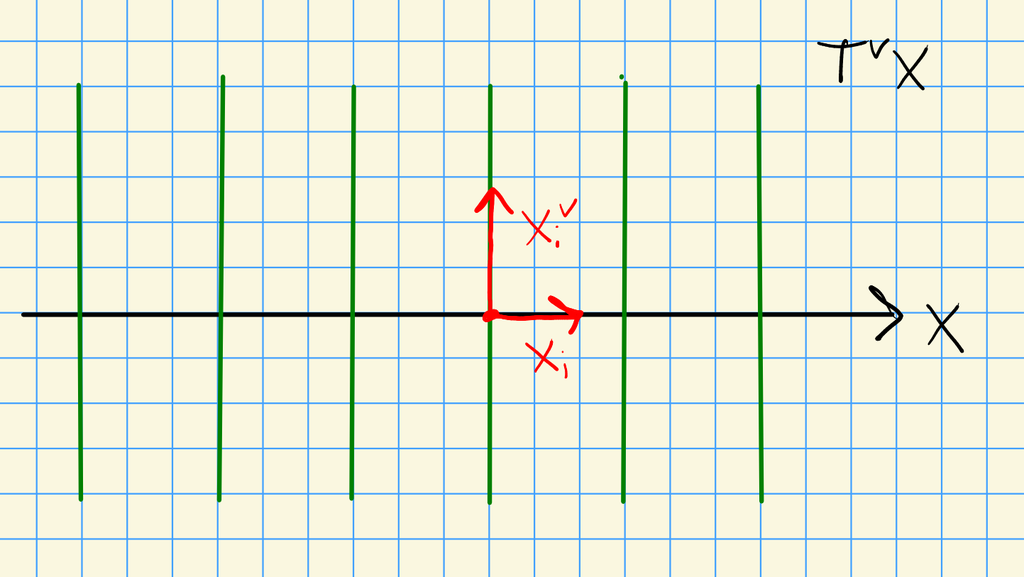

So we can write
$$\begin{align*}
\lambda = \sum y_i \,dx_i \in \Omega^1({\mathbf{T}} {}^{ \vee }X)
,\end{align*}
regarding the \(y_i\) as functions on \({\mathbf{T}} {}^{ \vee }X\) and \(\,dx_i\) as 1-forms on \({\mathbf{T}} {}^{ \vee }X\).$$

Find out what $\beta = \sum a_i \,dx_i$ is equal to as a section of ${\mathbf{T}} {}^{ \vee }X$.

To get a contact manifold of dimension $2n+1$, consider the 1-jet space $J^1(X) \mathrel{\vcenter{:}}= T {}^{ \vee }X \times {\mathbb{R}}$. Write the coordinates as $(x,y)\in {\mathbf{T}} {}^{ \vee }X$ and $z\in {\mathbb{R}}$ and define $\alpha = \,dz- \lambda$, the claim is that this is contact.

For dimension $2n-1$, choose a cometric on $X$ and take ${\mathbb{S}}{\mathbf{T}} {}^{ \vee }X$ the unit cotangent bundle of unit-length covectors. Then $\alpha \mathrel{\vcenter{:}}=-{ \left.{{\lambda}} \right|_{{{\mathbb{S}}{\mathbf{T}} {}^{ \vee }X}} }$ is contact.

Check that ${\mathbb{R}}^3 = J^1({\mathbb{R}})$ and ${\mathbb{S}}{\mathbf{T}} {}^{ \vee }({\mathbb{R}}^2) = {\mathbb{R}}^2 \times S^1$.

A neat theorem: the contact geometry of ${\mathbb{S}}{\mathbf{T}} {}^{ \vee }{\mathbb{R}}^3$ is a perfect knot invariant. This involves assigning to knots unique Legendrian submanifolds.

## 2.2 Perturbing Foliation

Define
$$\begin{align*}
\alpha_t = \,dz- ty\,dx\qquad t\in {\mathbb{R}}
\end{align*}
to get a 1-parameter family of 1-forms. Check that \(\alpha_t \wedge d \alpha_t = t(\,dz\wedge \,dx\wedge \,dy)\). Consider \(t\in (-{\varepsilon}, {\varepsilon})\):$$

What is a (codimension $r$) foliation on an $n{\hbox{-}}$manifold? A local diffeomorphism $U\cong {\mathbb{R}}^n \times {\mathbb{R}}^{n-r}$ with *leaves* ${\operatorname{pt}}\times{\mathbb{R}}^{n-r}$. For example, ${\mathbb{R}}^3\cong {\mathbb{R}}\times{\mathbb{R}}^2$ with coordinates $t$ and $(x, y)$. We’re leaving out a lot about how many derivatives one needs here!

> For a fiber bundle or vector bundle to admit an interesting foliation, one needs a flat connection.

Any $\xi \mathrel{\vcenter{:}}=\ker \alpha$ is **integrable** iff for all vector fields $X, Y \subseteq \xi$, their Lie bracket $[X, Y] \subseteq \xi$.

For $\alpha$ nonvanishing on $Y^3$, $\ker \alpha$ is tangent to a foliation by surfaces iff $\alpha \wedge d\alpha = 0$.

Consider $\alpha = \,dz- y\,dx$, so $\ker \alpha = \mathop{\mathrm{span}}_{\mathbb{R}}\left\{{{\partial}y, y{\partial}z + {\partial}x}\right\}$ which bracket to ${\partial}z \not \in \ker \alpha$. This yields a non-integrable contact structure.

On the other hand, for $\alpha = \,dz$, $\ker \alpha = \mathop{\mathrm{span}}_{\mathbb{R}}\left\{{{\partial}x, {\partial}y}\right\}$ which bracket to zero. So this yields a foliation.

A theorem of Eliashberg and Thurston: taut foliations can be perturbed to a (tight) positive contact structure.

# 3 Tuesday, January 18

Refs:

- Geiges, Intro to Contact
- Ozbogi-Stipsicz
- Etnyre lecture notes
- Massot
- Sivck

For $S^3 \subseteq {\mathbb{C}}^2$, define a form on ${\mathbb{R}}^4$ as
$$\begin{align*}
\alpha \mathrel{\vcenter{:}}=-y_1 dx_1 + x_1 dy_1 - y_2 dx_2 + x_2 dy_2
.\end{align*}
Then then standard contact form on \(S^3\) is
\begin{align*}
\xi_{\text{std}} \mathrel{\vcenter{:}}=\ker { \left.{{\alpha}} \right|_{{S^3}} }
.\end{align*}$$

Show that $\alpha$ defines a contact form.

Write $f = x_1^2 + y_1^2 + x_2^2 + y_2^2$, then
$$\begin{align*}
{ \left.{{ \alpha}} \right|_{{S^3}} } \wedge { \left.{{ d\alpha}} \right|_{{S^3}} } > 0 \iff df\wedge d \alpha \wedge d \alpha > 0
.\end{align*}$$

Check that

- $d\alpha = 2(dx_1 \wedge dy_1) + 2(dx_2 + dy_2)$
- $df = 2(x_1 dx_1 + y_1 dy_1) + 2(x_2 dx_2 + y_2 dy_2)$.

Note that at $p= {\left[ {1,0,0,0} \right]} \subseteq S^3$, ${\mathbf{T}}_pS^3 = \mathop{\mathrm{span}}\left\{{{\partial}y_1, {\partial}x_2, {\partial}y_2}\right\}$. and $\alpha_p = -0 dx_1 + 1dy_1 -0 dx_2 + 0dy_2 = dy_1$ and $\xi_p = \ker dy_1 = \mathop{\mathrm{span}}\left\{{{\partial}x_1, {\partial}y_2}\right\}$.

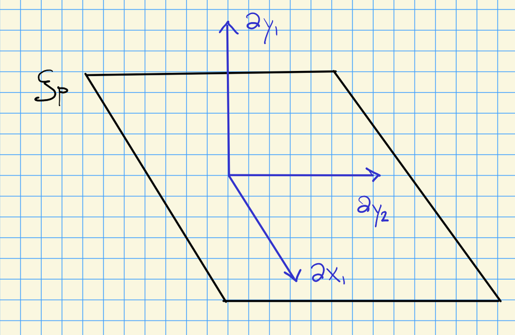

Then $\xi_p \leq {\mathbf{T}}_p {\mathbb{C}}^2 = \mathop{\mathrm{span}}\left\{{{\partial}x_1, {\partial}y_1, {\partial}x_2, {\partial}y_2}\right\} \cong {\mathbb{C}}^4$ is a distinguished complex line.

An **almost complex structure** on $X$ is a bundle automorphism $J: {\mathbf{T}}X{\circlearrowleft}$ with $J^2 = -\operatorname{id}$.

For $X = {\mathbb{C}}^2$, take
$$\begin{align*}
{\partial}x_1 &\mapsto {\partial}y_1 \\
{\partial}y_1 &\mapsto - {\partial}x_1 \\
{\partial}x_2 &\mapsto {\partial}y_2 \\
{\partial}y_2 &\mapsto -{\partial}x_2
.\end{align*}$$

Show that $f: {\mathbb{C}}\to {\mathbb{C}}$ is holomorphic if $df \circ J = J \circ df$, which corresponds to the Cauchy-Riemann equations.

Given $J:W\to W$, an ${\mathbb{R}}{\hbox{-}}$subspace $V \leq W$ is a ${\mathbb{C}}{\hbox{-}}$subspace iff $J(V) = V$.

The field of $J{\hbox{-}}$complex tangents is the hyperplane field
$$\begin{align*}
\xi_p \mathrel{\vcenter{:}}={\mathbf{T}}S^3 \cap J({\mathbf{T}}S^3)
.\end{align*}$$

Consider ${\mathbf{T}}_p S^3$ for $p={\left[ {1,0,0,0} \right]}$, then
$$\begin{align*}
J(\mathop{\mathrm{span}}\left\{{{\partial}y_1, {\partial}x_1, {\partial}y_2}\right\}) = \mathop{\mathrm{span}}\left\{{-{\partial}x_1, {\partial}y_2, -{\partial}x_2}\right\}
,\end{align*}
so \(\xi_p = \mathop{\mathrm{span}}{ {\partial}x_1, {\partial}y_2}\) is the intersection and coincides \(\xi_{\text{std}}\).$$

Where does $\alpha$ come from?

Let $\rho = \sum x_i {\partial}x_i + \sum y_i {\partial}y_i$ be the radial vector field, so $\rho = {1\over 2}\operatorname{grad}{\left[ {\sum x_i^2 + \sum y_i^2} \right]}$. Setting $\omega \mathrel{\vcenter{:}}=\bigwedge dx_i \wedge \bigwedge dy_i$, then $\alpha = \iota_p\omega \mathrel{\vcenter{:}}=\omega(p, {-})$ is the interior product of $\omega$. Then
$$\begin{align*}
\alpha = dx_1 \wedge dy_1 (x_1 {\partial}x_1 + y_1 {\partial}y_1 + \cdots ) + \cdots = x_1 dy_1 -y_1 dx_1 + \cdots
.\end{align*}
So the contact form comes from pairing the symplectic form against a radial vector field.$$

Recall $f \mathrel{\vcenter{:}}=\sum x_i^2 + \sum y_i^2$ satisfies $df = 2\sum x_i dx_i + 2\sum y_i dy_i$. Note that $J$ acts on 1-forms by $J^*(dx)({-}) = dx(J({-}))$. For $J = i$,

- $\delta x: dx(J {\partial}x) = dx({\partial}y) = 0$,
- ${\partial}y: dx(J {\partial}y) = dx(-{\partial}x) = -1$.

So $J^*(dx) = -dy$, and
$$\begin{align*}
J^*(df) = 2x_1 (-dy_1) + 2y_1 (dx_1) + 2x_2 (-dy_2) + 2y_2 (dx_2) = -2 \alpha
.\end{align*}$$

Thus $J^*(df)$ is a rotation of $df$ by $\pi/2$.

The field of complex tangencies along $Y = f^{-1}(0)$ is the kernel of ${ \left.{{ df(J({-})) }} \right|_{{Y}} }$.

Methods of getting contact structures: for a vector field $X$, being contact comes from ${\mathcal{L}}_X \omega = \omega$. For functions $f:{\mathbb{C}}^2 \to {\mathbb{R}}$, being contact comes from $\alpha = d^{\mathbb{C}}f$ being contact. See strictly plurisubharmonic functions and Levi pseudoconvex subspaces.

The standard contact structure is orthogonal to the Hopf fibration: define a map
$$\begin{align*}
{\mathbb{C}}^2\setminus\left\{{0}\right\}&\to {\mathbb{CP}}^1 \cong S^2 \\
{\left[ {z, w} \right]} &\mapsto {\left[ {z: w} \right]}
,\end{align*}
which restricts to a map \(S^3\to S^2\) defining the Hopf fibration. If \(L\) is a complex line through 0, then \(L \cap S^3\) is a Hopf fiber that is homeomorphic to \(S^1\).$$

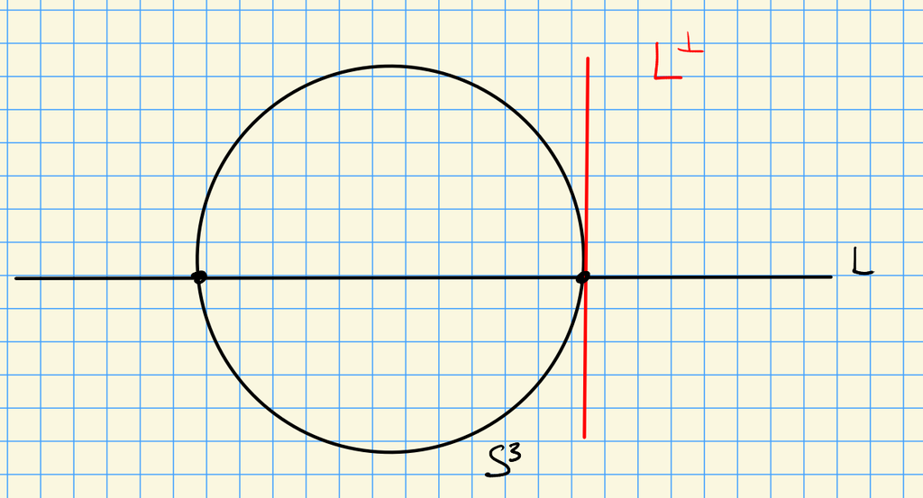

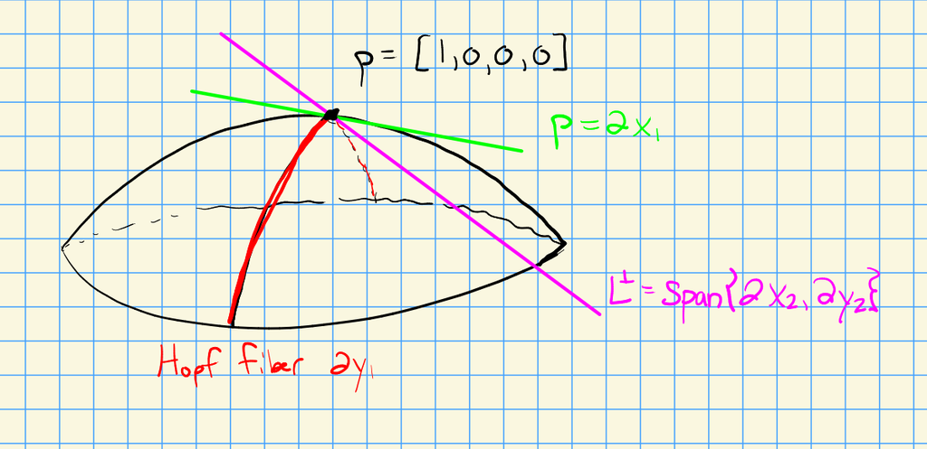

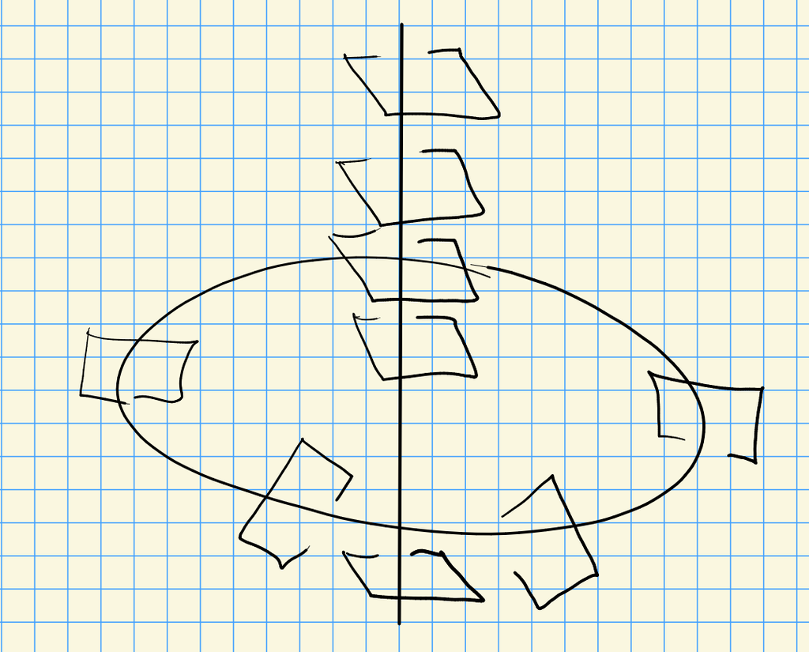

Take
$$\begin{align*}
{\mathbb{C}}^2 &\to {\mathbb{R}}^2 \\
(z_1, z_2)&\mapsto ({\left\lvert {z_1} \right\rvert}, {\left\lvert {z_2} \right\rvert})
.\end{align*}
Consider the image of \(S^2 = \left\{{{\left\lvert {z_1} \right\rvert}^2 + {\left\lvert {z_2} \right\rvert}^2 = 1}\right\}\):$$

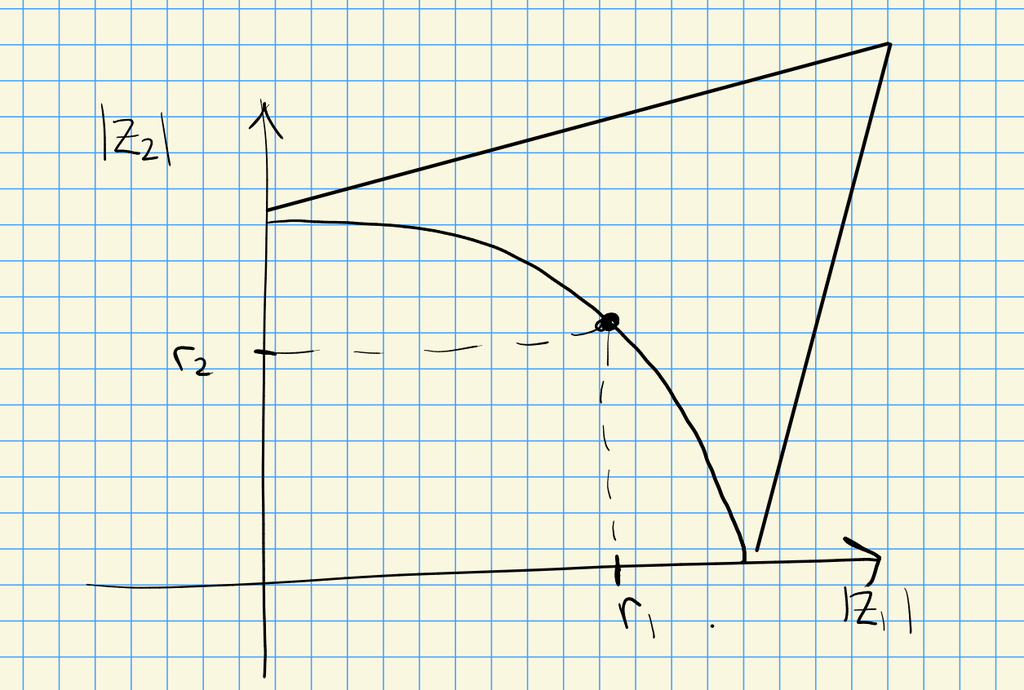

The preimage is $S^1\times S^1$. This can be realized as a tetrahedron with sides identified:

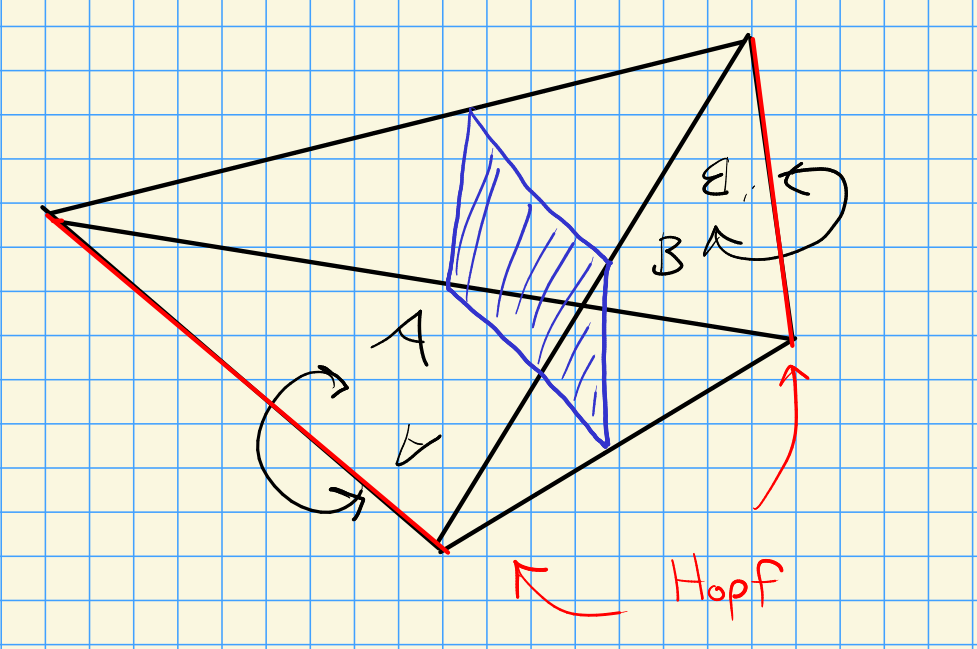

There are Hopf fibers on the ends, and undergo a $\pi/2$ twist as you move through the tetrahedron.

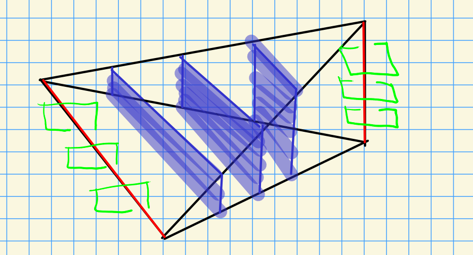

# 4 Darboux and Gromov Stability (Thursday, January 20)

Almost-complex structures: weaker than an actual complex structure, but not necessarily integrable. Useful for studying pseudoholomorphic curves. A necessary and sufficient condition for integrability: the Nijenhuis tensor $N_J = 0$ iff $J$ is integrable. In real dimension 2, all $J$ are integrable.

If $(Y^3, \xi)$ is contact then for every point $p$ there is a chart $U$ with coordinates $x,y,z$ where $\xi = \ker (\,dz-y\,dx) = \ker (\alpha_\text{std})$.

Locally, all contact *structures* (not necessarily forms) look the same. The mantra: local flexibility vs global rigidity.

## 4.1 Proof of Darboux

Two proofs:

- Geometric, due to Giroux
- PDEs, which generalizes. This uses Moser’s trick.

Locally write $\xi = \ker \alpha$ with $\alpha \wedge d \alpha > 0$. Pick a contact plane $\xi_p$ and let $S$ be a transverse surface, so ${\mathbf{T}}_p S \pitchfork\xi_p$. This produces a set of curves in $S$ which are tangent to $\xi_p$ everywhere, called the *characteristic foliation*.

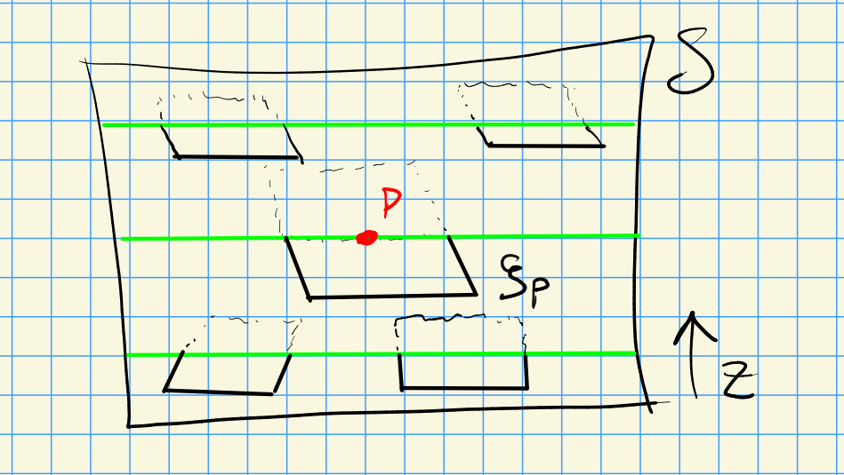

Then ${ \left.{{\alpha}} \right|_{{S}} } = \,dz$, which is a 1-form that is nonvanishing near $p$ and is locally integrable. Sending $\alpha \to X$ a vector field along $S$ yields a set of integral curves tracing out the characteristic foliation. This yields an $x$ direction and a $z$ direction on $S$ by flowing $t\in (-{\varepsilon}, {\varepsilon})$ around $p$ along $X$.

Choose a vector field ${\partial}t$ which is transverse to $S$ and contained in $\xi$. Then $\alpha({\partial}t) = 0$, so we can write
$$\begin{align*}
\alpha = f\,dx+ g\,dz+ h\,dt= f\,dx+ g\,dz
.\end{align*}
Since \(g(p) = 1\), replace \(\alpha\) with \({1\over g}\alpha\) which is positive near \(p\) and doesn’t change the contact structure \(\xi\). So write
\begin{align*}
\alpha = f\,dx+ \,dz
\implies
\alpha \wedge d \alpha = \alpha \wedge \qty{ f_t \,dy\wedge \,dx+ f_z \,dz\wedge \,dx} = -f_t \,dx\wedge \,dt\wedge \,dz> 0
,\end{align*}
meaning \(f_t <0\) and we can set \(y = f(x,z,t)\). This yields
\begin{align*}
\alpha = \,dz+ f\,dx= \,dz- y\,dx
.\end{align*}$$

By a linear change of coordinates, choose $x,y$ along $\xi$ to write $\alpha_p = \,dz$ and $\xi_p = \mathop{\mathrm{span}}{{\partial}x, {\partial}y}$:

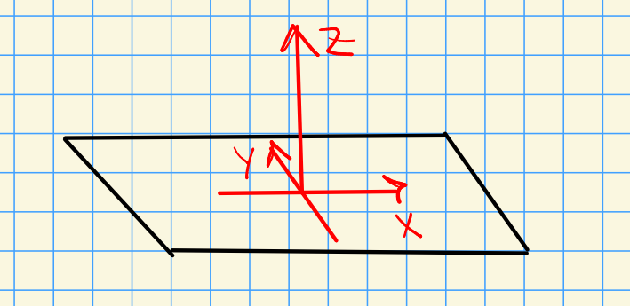

Write $(\alpha_0)_p$ for the original form and $\alpha_1 = \,dz- y\,dx$ the standard form, then the claim is that $\alpha_0 \simeq\alpha_1$ through a path of contact forms.

In a neighborhood of $p$, there is a family $\alpha_t$ for $t\in [0, 1]$.

To obtain this, interpolate:
$$\begin{align*}
d\alpha_t = t d\alpha_1 + (1-t) d\alpha_0
\implies \alpha_t \wedge d\alpha_t = t^2 \alpha_1 \wedge d\alpha_1 + t(1-t) (\alpha_0 \wedge d\alpha_1 + \alpha_1 \wedge d\alpha_0) + (1-t)^2 \alpha_0 \wedge d\alpha_0
.\end{align*}
The first and last terms are positive since the \(\alpha_i\) are contact. For the middle term, \(\alpha_0 = \alpha_1\) near \(p\), so by continuity this is positive in some neighborhood of \(p\).$$

Note that $\dot\alpha_t \mathrel{\vcenter{:}}={\frac{\partial }{\partial t}\,} \alpha_t$, so
$$\begin{align*}
{\frac{\partial }{\partial t}\,} \qty{ t\alpha_1 + (1-t) \alpha_0} = \alpha_1 - \alpha_0
.\end{align*}$$

We’ll assume that there is a time-dependent vector field $V_t \in \xi_t$ with flow $\Phi_t$ such that $(\Phi_t)_*(\xi_t) = \xi_0$. We’ll also require $\xi_t = \ker \alpha_t$, so this is a contactomorphism for each $t$. The goal is to show $(\Phi_1)_*(\xi_0) = \xi_1$, or equivalently $\Phi_t^* \alpha_t = f_t \alpha_0$ with $f_t > 0$. Take ${\frac{\partial }{\partial t}\,}$ of both sides here to get
$$\begin{align*}
\Phi_t^*( \dot \alpha_t + {\mathcal{L}}_{V_t} \alpha_t ) = \dot f_t \alpha_0
.\end{align*}$$

> See Prop 6.4 in Cannas da Silva.

✨Cartan’s magic formula✨:
$$\begin{align*}
{\mathcal{L}}_V(\alpha) = d(\iota_V \alpha) + \iota_V(d\alpha)
,\end{align*}
so
\begin{align*}
{\mathcal{L}}_{V_t}(\alpha_t) = d(\alpha_t(V_t)) + d\alpha_t(V_t, {-}) = 0 + d\alpha_t(V_t, {-})
.\end{align*}$$

We can thus write this equation as
$$\begin{align*}
\Phi_t^*(\dot \alpha_t + d\alpha_t(V_t, {-})) = \dot f_t \alpha_0 = \dot f_t \qty{\Phi_t^*(\alpha_t) \over f_t }
.\end{align*}
Applying \((\Phi_t^*)^{-1}\) yields
\begin{align*}
\dot \alpha_t + d\alpha_t(V_t, {-})= {\dot f_t \over f_t }\alpha_t
.\end{align*}
Now try to solve this for \(V_t\). Let \(R_t\) be the Reeb vector field of \(\alpha_t\), which satisfies$$

- $\alpha_t(R_t) = 1$
- $d\alpha_t(R_t, {-}) = 0$.

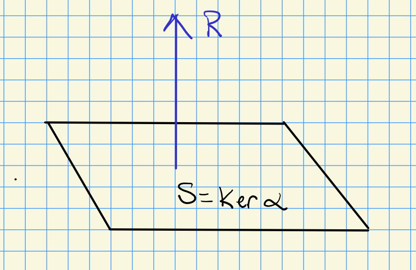

Then
$$\begin{align*}
\dot \alpha_t (R_t) = {\dot f_t \over f_t} = {\frac{\partial }{\partial t}\,} \log(f_t) \mathrel{\vcenter{:}}=\mu_t
,\end{align*}
so \(\dot\alpha_t(R_t)\) determines \(f_t\) by first integrating and exponentiating.$$

We now need to solve
$$\begin{align*}
{ \left.{{d\alpha_t(V_t, {-})}} \right|_{{\xi_t}} } = { \left.{{\mu_t \alpha_t - \dot \alpha_t}} \right|_{{\xi_t}} }
.\end{align*}
Since \(d \alpha_t\) is a volume form on \(\xi_t\), it identifies vector fields in \(\xi_t\) with 1-forms on \(\xi_t\) using the happy coincidence that \(n=2\) so \(1\mapsto n-1 = 1\). So \(V_t\) is uniquely determined by the solution to the above equation.$$

# 5 Gray Stability (Tuesday, January 25)

A homotopy of contact structures o $Y^3$ is a smooth family $\left\{{\phi_t}\right\}$ of contact structures. Similarly, an **isotopy** of structures such that $\left\{{D\phi_t(\xi_0)}\right\}$ for an isotopy $\phi_t: Y\to Y$ with $\phi_0 = \operatorname{id}$. If $Y^3$ is closed then every homotopy of contact structures is an isotopy. Theorem: contact structures mod isotopy is discrete, which critically uses closedness.

For $\phi_t$ an isotopy generated by the flow of $X_t$ and $\alpha_t$ a family of 1-forms,
$$\begin{align*}
{\frac{\partial }{\partial t}\,} \phi^*_t(\alpha_t) \mathrel{\Big|}_{t=t_0} = \phi_{t_0}^*(\dot \alpha_{t_0} + {\mathcal{L}}_{X_{t_0}} \alpha_{t_0} )
.\end{align*}$$

Write
$$\begin{align*}
\phi_x^*(\alpha_y) = {\frac{\partial }{\partial x}\,} ? + {\frac{\partial }{\partial y}\,}? = \phi_{x_0}^* {\mathcal{L}}_{X_0} {\mathcal{L}}_X \alpha_{y_0} + \phi_{x_0}^* \alpha_y
,\end{align*}
and proceed similarly to the proof of Darboux’s theorem.$$

Pick $\left\{{\phi_t}\right\}$ a homotopy, one can choose $\alpha_t$ with $\xi_t = \ker \alpha_t$ for all $t$. Apply Moser’s trick: assume there exists a $\phi_t$ with $\phi_t^*(\alpha_t) = \lambda_t \alpha_0$ and try to find $v_t$ generating it, where $\lambda_t: Y\to {\mathbb{R}}_+$. What does $\phi_t$ need to look like? Differentiate in $t$:
$$\begin{align*}
\phi^*_{t_0}(\cdot \alpha_{t_0} + {\mathcal{L}}_{V_{t_0}} \alpha_{t_0} ) = \dot \lambda_t \alpha_0 = \dot \lambda_t \qty{ \phi^*_{t_0} (\alpha_t) \over \lambda_t }
.\end{align*}
Apply \((\phi^*_{t_0})^{-1}\):
\begin{align*}
\cdot\alpha_t + {\mathcal{L}}_{V_t}\alpha_t = \mu_t \alpha_t\qquad \mu_t = (\phi^*_{t_0})^{-1}(\dot\lambda_t \over \lambda_t)
.\end{align*}
Use that \(V_t\) is always tangent to the contact structure, so \(V_t \in \xi_t\), to assume \(\alpha_t(V_t) =0\). Apply Cartan:
\begin{align*}
\dot \alpha_t + d\alpha_t(V_t) + \iota_{V_t} d\alpha_t = \mu_t \alpha_t
,\end{align*}
and \(d\alpha_t(V_t) = 0\), so
\begin{align*}
\iota_{V_t}d\alpha_t = \mu_t \alpha_t - \dot \alpha_t
.\end{align*}
Plug in the Reeb vector field \(R_t\), then \(\alpha_t(R_t) = 0\) so \(\mu_t = \dot \alpha_t (R_t)\).$$

Let $Y$ be n $S^3 \subseteq {\mathbb{C}}^2$ that is transverse to the radial vector field. Then
$$\begin{align*}
\alpha = x_1 dy_1 - y_1 dx_1 + x_2 dy_2 - y_2 dx_2\mathrel{\Big|}_y
\end{align*}
defines the standard tight contact structure.$$

Write $Y \subseteq {\mathbb{R}}\times S^3$ in coordinates $(f(x), x)$ as the graph of a function $f: S^3\to {\mathbb{R}}$. Take an isotopy $Y_t = (tf(x), x) \subseteq {\mathbb{R}}\times S^3$ to get a family of contact forms where $\alpha_0 = \alpha_\text{std}$ and $\alpha_1$ is some unknown form. By Gray stability, the contact structures are isotopic.

## 5.1 Legendrian Links

Let $Y$ be a contact 3-manifold and $L \hookrightarrow Y$ a link. Then $L$ is a **Legendrian knot** iff it is everywhere tangent to $\xi$, so $\alpha(L) = 0$:

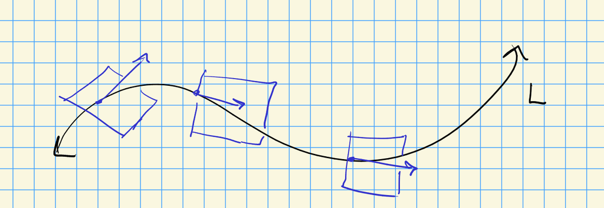

This is a closed condition.

$L$ is **transverse** if it is everywhere transverse to $\xi$, so $\alpha(L) > 0$:

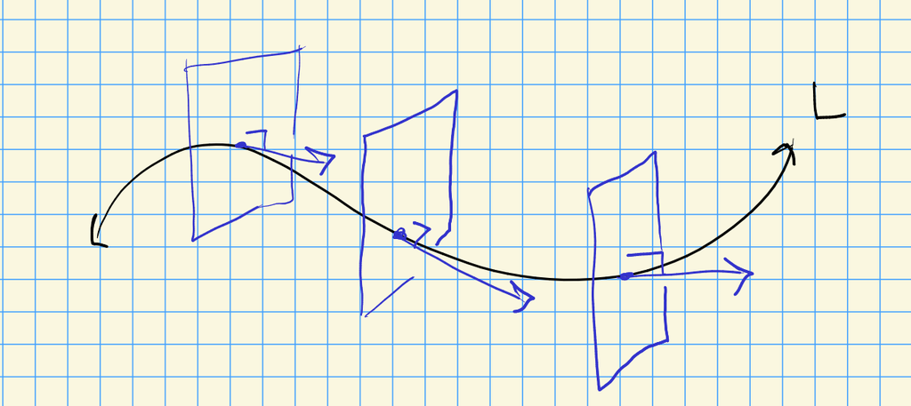

This is an open condition.

Every Legendrian knot has a transverse pushoff (up to transverse isotopy). Every transverse knot has a Legendrian approximation.

Take ${\mathbb{R}}^3$ and $\alpha_\text{std}= dz-ydx$, then the $y{\hbox{-}}$axis $L_1 \mathrel{\vcenter{:}}=\left\{{{\left[ {0,t,0} \right]}}\right\}$ is Legendrian. Similarly the $x{\hbox{-}}$axis $L_2$ is Legendrian, checking that ${\mathbf{T}}L_2 = \mathop{\mathrm{span}}\left\{{{\left[ {1,0,0} \right]}}\right\}$. However the slight pushoff $L_3 \mathrel{\vcenter{:}}=\left\{{{\left[ {t, -{\varepsilon}, 0} \right]}}\right\}$ is transverse since ${ \left.{{\alpha}} \right|_{{L_3}} } = {\varepsilon}dx >0$.

Every Legendrian has a neighborhood contactomorphic to the zero section in $J_1 S^1 = {\mathbf{T}}S^1 \times{\mathbb{R}}$. Every transverse has a neighborhood contactomorphic to the $z{\hbox{-}}$axis in ${\mathbb{R}}\times S^1$ with $\alpha \mathrel{\vcenter{:}}=\,dz+ r^2 \,d\theta$.

# 6 Thursday, January 27

Goal: classify Legendrian knots up to (Legendrian) isotopy. Recall a knot $\gamma: S^1 \hookrightarrow Y$ satisfies $\gamma^*(\alpha) = 0$, and a Legendrian isotopy is a 1-parameter family $\gamma_t$ which are Legendrian for all $t$.

$\gamma(s) = {\left[ {x(s), y(s), z(s)} \right]}$ and $\xi = \ker \alpha, \alpha = \,dz- y\,dx$. Then $\gamma^*(\alpha) = z' \,ds- yx^1\,ds= (z' - yx')\,ds$, which is Legendrian iff $y=z'/x'$.

Let $f:{\mathbb{R}}\to {\mathbb{R}}$ and take the 1-jet $\gamma(s) = {\left[ {s, f'(s), f(s)} \right]}$ of the graph of $f$ – this is like the graph of the 1st order Taylor expansion. This is Legendrian since $s'=1$ implies $z'/x' = f'/s' = f'$.

There are two projections:

- ${\left[ {x,y,z} \right]} \to {\left[ {x,z} \right]}$, a wave front projection, plotted with $y$ into the board,
- ${\left[ {x,y,z} \right]} \to {\left[ {x,y} \right]}$, Lagrangian projection.

Let $\gamma(s) = {\left[ {s^2, {3\over 2}s, s^3} \right]}$, then the two projections are as follows:

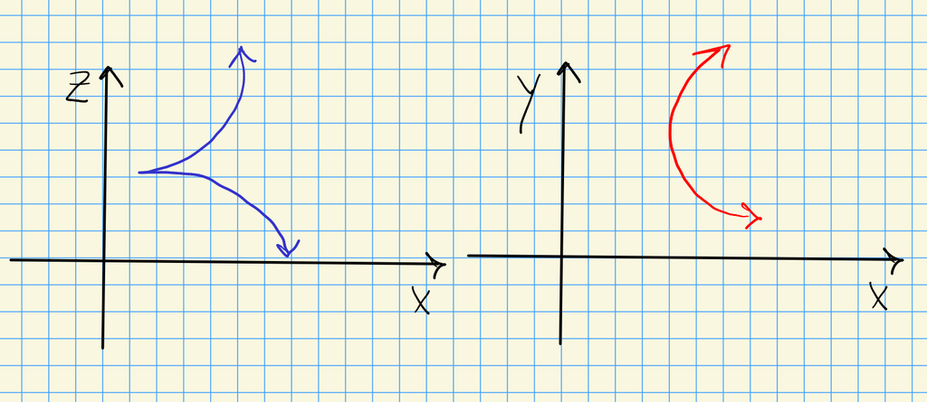

The front projection uniquely determines $L$, since the $y$ coordinate can be recovered as $y=z'/x'$. So for example, there is no ambiguity about crossing order: the more negatively sloped line in a diagram is the over-crossing:

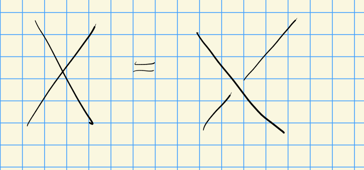

A front diagram of the unknot:

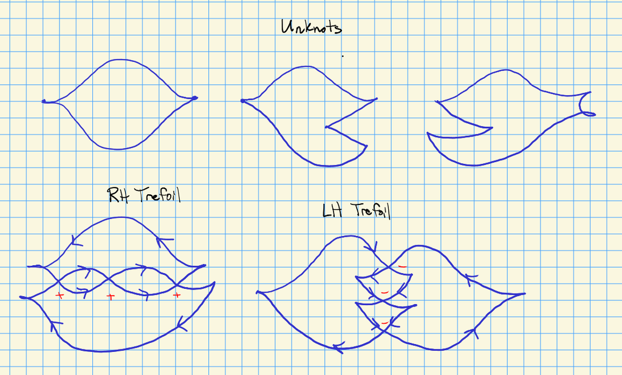

Every knot $K \hookrightarrow{\mathbb{R}}^3$ can be $C^0$ approximation by a Legendrian knot $L$.

Idea: zigzags in an ${\varepsilon}$ tube in the knot diagram, which will be Legendrian. How to measure: $\sup_{s\in I} {\left\lvert {\gamma_1(s) - \gamma_2(s)} \right\rvert} \leq {\varepsilon}$?

Note that $\mathsf{Lie}({\operatorname{SO}}_3) \mathrel{\vcenter{:}}={\mathbf{T}}_e({\operatorname{SO}}_3) = {\mathfrak{su}}_2$, spanned by roll, pitch, and yaw generators:

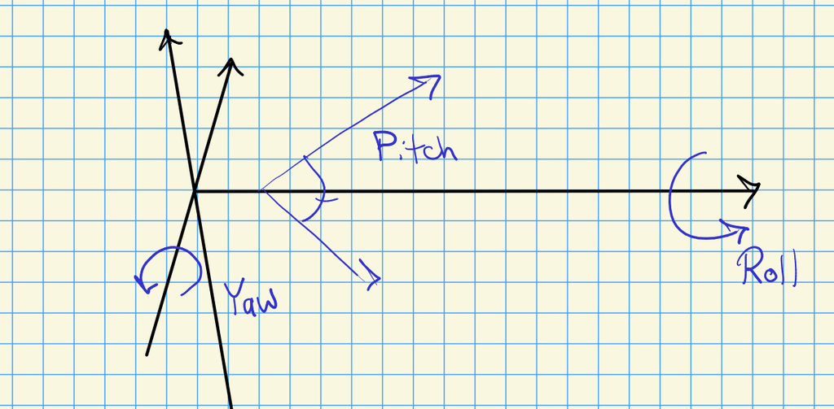

So measuring the number of rotations along each generator after traversing $L$ in a full loop yields integer invariants.

A **framing** of a knot $K$ is a trivialization of its normal bundle, so an identification of $\nu(K) \cong S^1\times {\mathbb{D}}^2$. The potential framings are in $\pi_1({\operatorname{SO}}_2) \cong \pi_1(S^1) \cong {\mathbb{Z}}$, since a single vector field normal (?) to the knot determines the framing by completing to an orthonormal basis. The Reeb vector field is never tangent to a Legendrian knot, so this determines a framing called the **contact framing**. The **Thurston–Bennequin number** is the different between the 0-framing and the contact framing. The 0-framing comes from a Seifert surface. This is an invariant of Legendrian knots, since Legendrian isotopy transports frames. Note that adding zigzags adds cusps, and thus decreases this number.

How to compute: take a pushoff and compute the linking number:

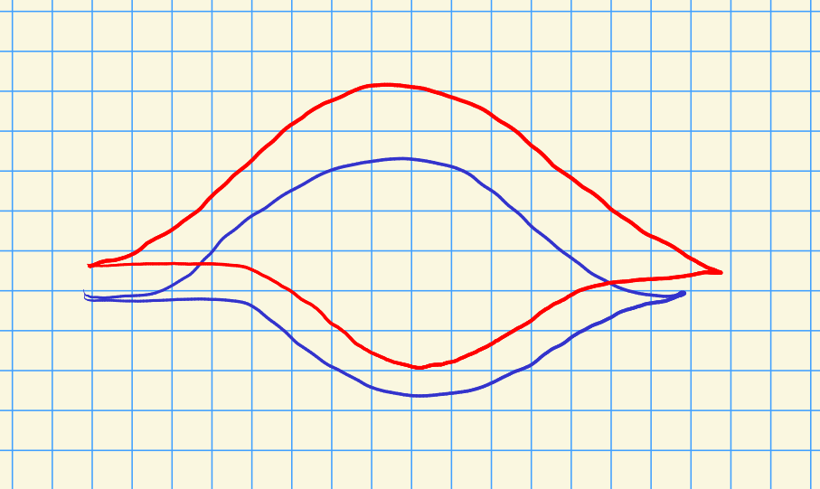

$$\begin{align*}
\mathrm{tb}(L) = w(L) - {1\over 2}C(L)
,\end{align*}
where \(w(L)\) is the writhe and \(C(L)\) is the number of cusps.$$

The linking number is ${1\over 2}(c_+(L) - c_-(L))$, half of the signed number of crossings.

Here all 4 crossing have the same sign:

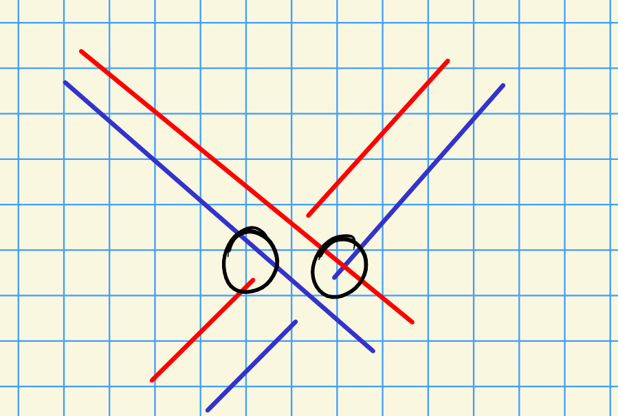

Since adding zigzags decreases $\mathrm{tb}$, define $\mathrm{TB}$ to be the max over all Legendrian representatives of $K$. This distinguishes mirror knots. In fact $\mathrm{tb}(L) \leq 2g_3(L) - 1$ (the Bennequin bound), involving the 3-genus.

The **rotation number** of $L$ is the *turning number* $\operatorname{rot}(L)$ in the Lagrangian projection, i.e. how many times a tangent vector spins after traversing the knot.

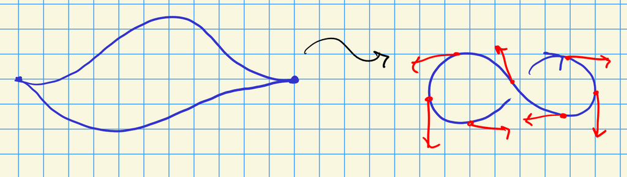

It turns out that
$$\begin{align*}
\operatorname{rot}(L) = {1\over 2}\qty{ {\sharp}\text{down cusps} - {\sharp}\text{up cusps}}
.\end{align*}$$

# 7 Tuesday, February 01

Last time: front diagrams ${\left[ {x,y,z} \right]}\mapsto {\left[ {x,z} \right]}$, where $\alpha = \,dz-y\,dx$ forces $y=\,ds/\,dx$ can be recovered as the slope in the projection. Note that we can also recover crossing information from the Legendrian condition, since $y$ always points into the board, so more negative slopes go on top.

Some invariants:

- Thurston-Bennequin invariant: a contact framing with respect to the Reeb vector field

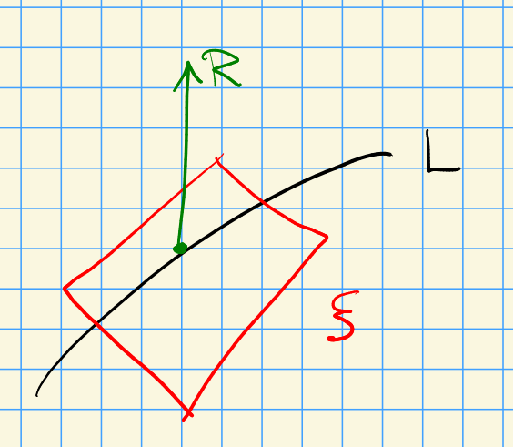

- Equal to writhe minus half the number of cusps.
- Rotation numbers: Turning number of $L$ with respect to $\xi$, after fixing a trivialization of $\xi$. Equal to ${1\over 2}(D-U)$, the number of down/up cusps respectively.

Disallowed moves:

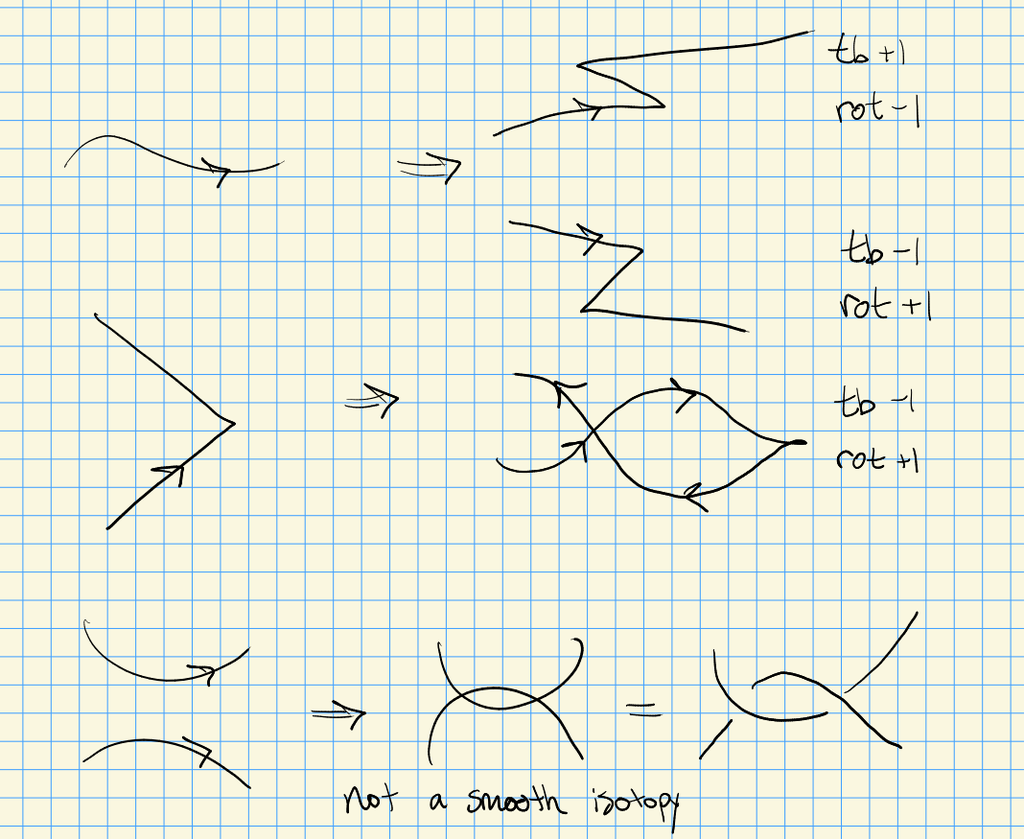

Allowed moves:

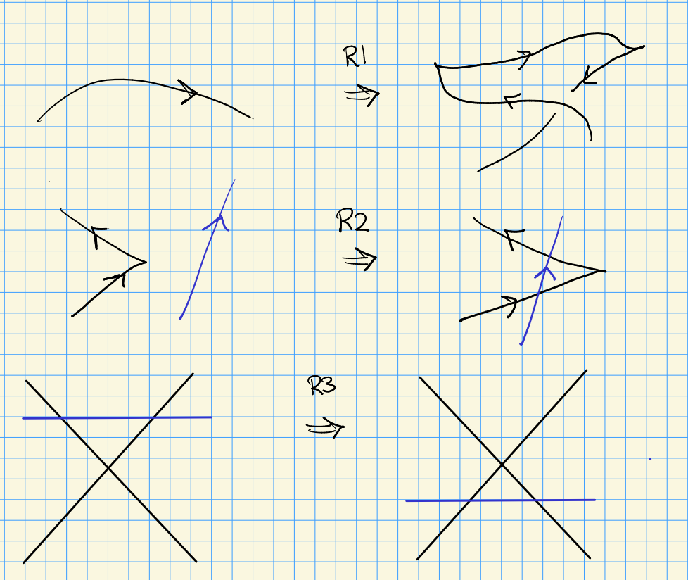

Geography problem: given a smooth knot $K$, which pairs $(t, r) \in {\mathbb{Z}}^2$ are realized as $(\mathrm{tb}(L), \operatorname{rot}(L))$ for $L$ a Legendrian representative of $K$?

Botany problem: given $(t, r) \in {\mathbb{Z}}^2$, how many inequivalent $L$ representing $K$ realize $(t,r) = (\mathrm{tb}(L), \operatorname{rot}(L))$?

For $K$ the unknot:

[figure not shown]

So these numerical pairs fall into a cone:

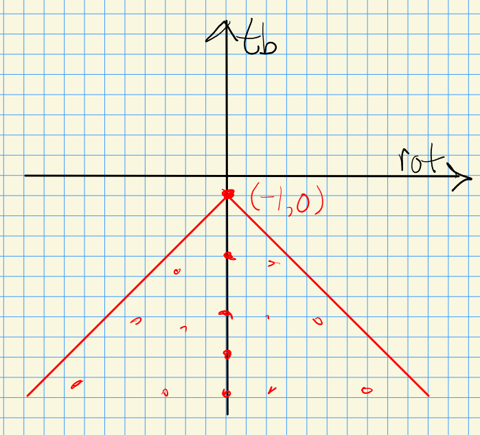

For $L \subseteq {\mathbb{R}}^3$ a Legendrian knot,
$$\begin{align*}
\mathrm{tb}(L) + \operatorname{rot}(L) \equiv 1 \operatorname{mod}2
.\end{align*}$$

Note that $\chi(S) \equiv 1\operatorname{mod}2$ for $S$ a Seifert surface.

For any Seifert surface $S$,
$$\begin{align*}
\mathrm{tb}(L) + {\left\lvert { \operatorname{rot}(L) } \right\rvert} \leq -\chi(S)
.\end{align*}$$

This solves the geography problem: this cone contains all of the possible pairs.

The unknot is **Legendrian simple**: if $\mathrm{tb}(L_1) = \mathrm{tb}(L_2)$ and $\operatorname{rot}(L_1) = \operatorname{rot}(L_2)$, then $L_1$ is isotopic to $L_2$.

This solves the botany problem: every red dot has exactly one representative.

Other knots are Legendrian simple, e.g. the trefoil. A theorem of Checkanov says the following $5_2$ knots are not Legendrian isotopic:

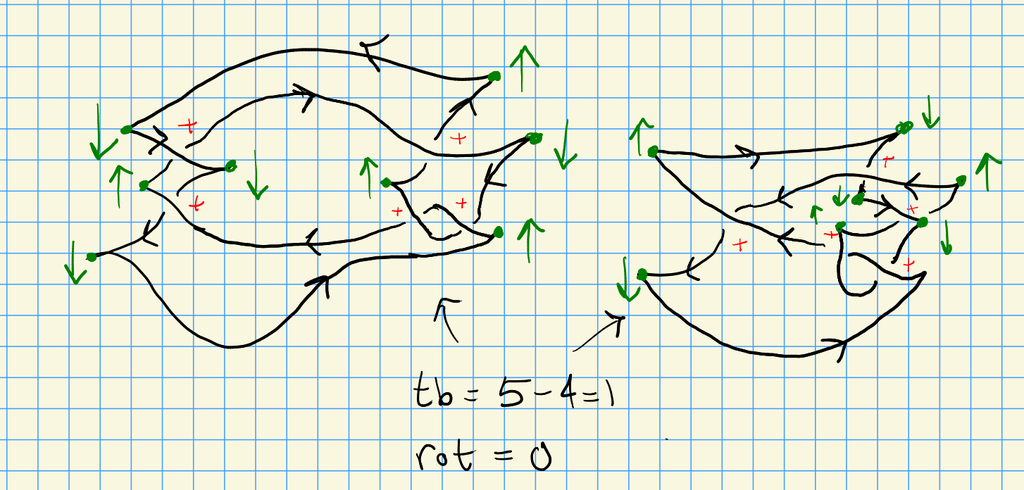

This all depended on the standard contact form. Consider instead the overtwisted disc: take ${\mathbb{R}}^3$ with $\alpha = \cos(r)\,dz+ \sin(r) \,d\theta$. Take the curve ${\left[ {r,\theta, z} \right]} = \gamma(t) \mathrel{\vcenter{:}}={\left[ {1, t, 0} \right]}$, a copy of $S^1$ in the $x,y{\hbox{-}}$plane. Then $\gamma' = {\left[ {0,1,0} \right]}$, and at $\theta=\pi, \alpha = \cos(\pi)\,dz+ \sin(\pi) \,d\theta= -\,dz$, but at $r=0$ $\alpha = \,dz$, so traversing a ray from $0$ to $-1$ in the $x,y{\hbox{-}}$plane forces the contact plane to flip:

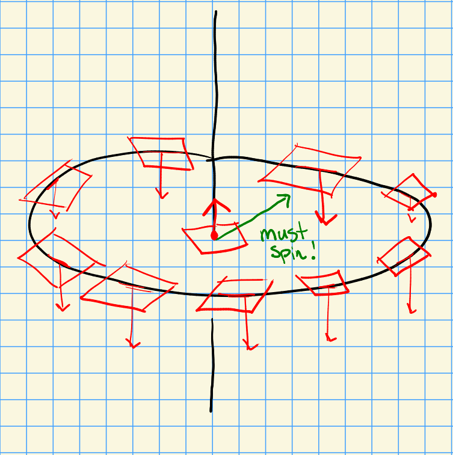

One can check that $\mathrm{tb}$ is given my $\operatorname{lk}(L, L') = 0$ where $L'$ is a pushoff of $L$, and can be made totally disjoint from $L$ in this case by moving in the $z{\hbox{-}}$plane.

An **overtwisted disc** in $(Y^3, \xi)$ that is locally contactomorphic to this local model. $Y$ is **overtwisted** if it contains an overtwisted disc, and is tight otherwise.

$({\mathbb{R}}^3, \xi_\text{std})$ is a tight contact structure.

For every closed oriented $Y^3$, every homotopy class of 2-plane fields on $Y$ contains a unique (up to isotopy) overtwisted contact structure.